# 分类模型评估、k 近邻分类

## 一、实验目的

熟悉分类模型的评估和性能度量方法,掌握分类器调参和训练的一般步骤。

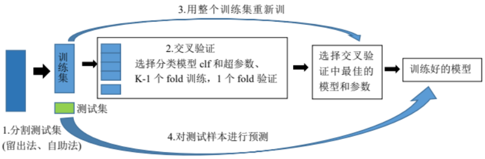

## 二、实验内容

### 1、编写以下性能度量函数

准确率（get_accuracy）、查准率（get_precision）、查全率（get_recall）、F1度量（get_F1-measure）。以上每个函数输入(y, y_predicted)，两个参数分别为真实标签和预测出来的标签。

```python
a = [1, 0, 0, 1, 0]
b = [0, 0, 0, 1, 0]
```

- 准确率

```python
def get_accuracy(y:list, y_predicted:list):
    sum = 0
    for i in zip(y, y_predicted):
        if i[0] == i[1]:
            sum += 1
    sum /= len(y)
    return sum
print(get_accuracy(a, b))
```

```
0.8
```

- 查准率

```python
def get_precision(y:list, y_predicted:list):
    TP = 0  # 真正例
    TN = 0  # 真反例
    FP = 0  # 假正例
    FN = 0  # 假反例
    for i in zip(y, y_predicted):
        if i[0] == i[1] == 1:
            TP += 1
        elif i[0] == i[1] == 0:
            TN += 1
        elif i[0] == 0 and i[1] == 1:
            FP += 1
        elif i[0] == 1 and i[1] == 0:
            FN += 1
    return TP / (TP + FP)
print(get_precision(a, b))
```

```
1.0
```

- 查全率

```python
def get_recall(y:list, y_predicted:list):
    TP = 0  # 真正例
    TN = 0  # 真反例
    FP = 0  # 假正例
    FN = 0  # 假反例
    for i in zip(y, y_predicted):
        if i[0] == i[1] == 1:
            TP += 1
        elif i[0] == i[1] == 0:
            TN += 1
        elif i[0] == 0 and i[1] == 1:
            FP += 1
        elif i[0] == 1 and i[1] == 0:
            FN += 1
    return TP / (TP + FN)
print(get_recall(a, b))
```

```
0.5
```

- F1度量

```python
def get_F1_measure(y:list, y_predicted:list):
    P = get_precision(y, y_predicted)
    R = get_recall(y, y_predicted)
    F1 = 2 * P * R / (P + R)
    return F1
print(get_F1_measure(a, b))
```

```
0.6666666666666666
```

### 2、编程实现三种常用模型评估方法

- 2.1 编程实现分层采样的留出法，该函数按照给定比例从每个类别划分出测试集：X_train, y_train, X_test, y_test=StrateSplit(X,y,test_ratio,random_state)。4 个输入分别为数据矩阵，标签，测试集比例，和随机种子，返回训练集数据、对应标签，以及测试集数据和对应标签。

```python
import random
# 留出法
def StrateSplit(x, y:list, test_ratio:float, random_state:float):
    X = x.copy(deep=True)
    random.seed(random_state)
    index = len(X.T)
    X.insert(index, 'target', y)
    temp = X.values
    random.shuffle(temp)
    lenth = int(test_ratio * len(temp))
    y_train = [row[index:] for row in temp[lenth:]]
    y_test = [row[index:] for row in temp[:lenth]]
    X_train = [row[:index] for row in temp[lenth:]]
    X_test = [row[:index] for row in temp[:lenth]]
    X_test = pd.DataFrame(X_test)
    y_test = pd.DataFrame(y_test)
    X_train = pd.DataFrame(X_train)
    y_train = pd.DataFrame(y_train)
    return X_train, y_train, X_test, y_test
```

- 2.2 编写有放回采样 BoostTr 划分测试集。 X_train, y_train, X_test, y_test=BoostTr(X,y,random_state)。该方法有放回采样 n 次得到训练集，n 为 X 中样本数目。未被采样到的样本为测试样本。

```python
# 自助法
def BoostTr(x, y, random_state:int):
    X = x.copy(deep=True)
    X_test = []
    n = len(X)
    random.seed(random_state)
    index = len(X.T)
    temp = X.values
    X_train = X.sample(n, replace=True)
    for i in list(X.values):
        flag = True
        for j in list(X_train.values):
            if (i == j).all():
                flag = False
                break
        if flag:
            X_test.append(i)
    X_test = pd.DataFrame(X_test)
    y_train = X_train.iloc[:,4:]
    X_train = X_train.iloc[:,:4]
    y_test = X_test.iloc[:,4:]
    X_test = X_test.iloc[:,:4]
    return X_train, y_train, X_test, y_test
```

- 2.3 编写 k 折随机划分：folds_index=KfoldSplit(n_sample, k, random_state)。输入为训练集样本数据，fold个数，以及随机种子,返回每个fold样本的index。

```python
import numpy as np
from sklearn.model_selection import KFold

def KfoldSplit(x, k, random_state):
    n_sample = x.copy(deep=True)
    kf = KFold(n_splits=k, shuffle=True, random_state=random_state)
    folds_index = []
    for test_index in kf.split(n_sample):
         folds_index.append(test_index)
    return pd.DataFrame(folds_index)
```

### 3、 编程实现 k 最近邻分类

- 编写 k-nearestN 函数，输入训练数据 X_train,其对应标签 y,近邻数 k，测试集 X_test，以及距离度量，输出测试集中每个样本的标签。默认距离度量为欧式距离，其他可选距离包括余弦相似度等。

```python
# 编造一些数据
train = [(2, 0), (2, 1), (0, 3), (1, 5), (1, 4), (2, 2), (2, 3), (2, 4)]
labels = ['red', 'red', 'blue', 'blue', 'red', 'blue', 'red', 'blue']
test = [(1, 1), (3, 3), (1, 3)]
def distance(x1, y1, x2, y2, distancetype):
    # 计算欧氏距离
    if distancetype == 'Euclidean':
        return ((x1 - x2)**2 + (y1 - y2)**2)**0.5
    # 计算余弦相似度
    elif distancetype == 'Cosline':
        return (x1*y1 + x2*y2)/((x1**2+y1**2)**(0.5+x2**2+y2**2)**0.5)
    # 计算曼哈顿距离
    elif distancetype == 'Manhattan':
        return (x1-y1) + (x2-y2)
    elif distancetype == 'Chebyshev':
        return max(x1-y1, x2-y2)
    # 其他各种距离同理

def k_nearestN(X_train, y, k, X_test:list, distancetype = 'Euclidean'):
    ret_labels = []
    for i in X_test:
        hash_table = {}
        temp = []
        for j in X_train:
            # 距离添加进列表
            temp.append(distance(i[0], i[1], j[0], j[1], distancetype))
        # 打包训练集的点和对应的距离
        temp = list(zip(temp, X_train, y))
        # 按每个元组的第一个元素(距离)排升序
        temp.sort(key = lambda x:x[0])
        temp = temp[0 : k]
        for e in temp:
            if e[2] in hash_table:
                hash_table[e[2]] += 1
            else:
                hash_table[e[2]] = 1
        max_value = 0
        max_key = ''
        for e in hash_table:
            if hash_table[e] > max_value:
                max_value = hash_table[e]
                max_key = e
        ret_labels.append(max_key)
    return ret_labels
# 各种距离的测试
print(k_nearestN(train, labels, 3, test))
print(k_nearestN(train, labels, 3, test, 'Cosline'))
print(k_nearestN(train, labels, 3, test, 'Manhattan'))
print(k_nearestN(train, labels, 3, test, 'Chebyshev'))
```

```
['red', 'blue', 'red']
['blue', 'blue', 'blue']
['blue', 'blue', 'blue']
['blue', 'blue', 'blue']
```

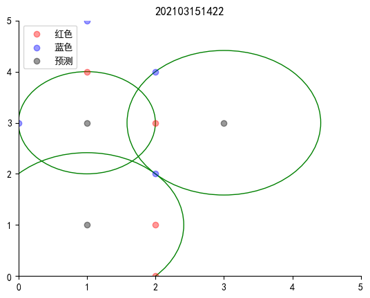

```python
# 对于欧式距离的作图验证
import matplotlib.pyplot as plt
import numpy as np
import os
plt.rcParams['font.sans-serif']=['SimHei']
plt.rcParams['axes.unicode_minus'] = False
X = np.array([2, 2, 1, 2])
Y = np.array([0, 1, 4, 3])
X1 = np.array([0, 1, 2, 2])
Y1 = np.array([3, 5, 2, 4])
X2 = np.array([1, 3, 1])
Y2 = np.array([1, 3, 3])

fig, ax = plt.subplots()
circle1 = plt.Circle((1, 1), radius=2**0.5, color='g', fill=False)
ax.add_artist(circle1)
circle2 = plt.Circle((3, 3), radius=2**0.5, color='g', fill=False)
ax.add_artist(circle2)
circle3 = plt.Circle((1, 3), radius=1, color='g', fill=False)
ax.add_artist(circle3)
plt.xlim(xmin = 0, xmax = 5)
plt.ylim(ymin = 0, ymax = 5)
plt.xticks(np.linspace(0, 5, 6))
plt.yticks(np.linspace(0, 5, 6))
ax = plt.gca()
ax.spines['top'].set_color('none')
ax.spines['right'].set_color('none')
plt.title('202103151422')
plt.scatter(X, Y, marker = 'o', alpha=0.4, color="red", label='红色')
plt.scatter(X1, Y1, marker = 'o', alpha=0.4, color="blue", label='蓝色')
plt.scatter(X2, Y2, marker = 'o', alpha=0.4, color="black", label='预测')

plt.legend()
plt.show()
```

### 4、基于 breast_cancer 数据集的分类实验。

- 4.1 从 sklearn.datasets 导入数据，查看样本数、属性数、类别数、以及每个类别的大小，得到数据 X 和标签 y。通过观察类别大小，你发现什么？这种情况下accuracy 是否是一种合适的度量，为什么？

```python
import pandas as pd
import random
import copy
# 导入一个二分类的数据集
from sklearn.datasets import load_breast_cancer
data = load_breast_cancer()
# 查看样本数
print("样本数是", len(data.data))
# 查看属性数
print("属性数是",len(data.target_names))
# 查看类别数
print("类别数是",len(data.feature_names))
# 查看每个类别的大小
for i in data.feature_names:
    print("类别", i, "的大小是", len(data.data))
dfx = pd.DataFrame(data.data)
dfy = pd.DataFrame(data.target)
print("数据x：")
print(dfx)
print("标签y：")
print(dfy)
df = pd.DataFrame(data.data)
```

```
样本数是 569
属性数是 2
类别数是 30
类别 mean radius 的大小是 569
类别 mean texture 的大小是 569
类别 mean perimeter 的大小是 569
类别 mean area 的大小是 569
类别 mean smoothness 的大小是 569
类别 mean compactness 的大小是 569
类别 mean concavity 的大小是 569
类别 mean concave points 的大小是 569
类别 mean symmetry 的大小是 569
类别 mean fractal dimension 的大小是 569
类别 radius error 的大小是 569
类别 texture error 的大小是 569
类别 perimeter error 的大小是 569
类别 area error 的大小是 569
类别 smoothness error 的大小是 569
类别 compactness error 的大小是 569
类别 concavity error 的大小是 569
类别 concave points error 的大小是 569
类别 symmetry error 的大小是 569
类别 fractal dimension error 的大小是 569
类别 worst radius 的大小是 569
类别 worst texture 的大小是 569
类别 worst perimeter 的大小是 569
类别 worst area 的大小是 569
类别 worst smoothness 的大小是 569
类别 worst compactness 的大小是 569
类别 worst concavity 的大小是 569
类别 worst concave points 的大小是 569
类别 worst symmetry 的大小是 569
类别 worst fractal dimension 的大小是 569
数据x：
        0      1       2       3        4        5        6        7       8   \
0    17.99  10.38  122.80  1001.0  0.11840  0.27760  0.30010  0.14710  0.2419
1    20.57  17.77  132.90  1326.0  0.08474  0.07864  0.08690  0.07017  0.1812
2    19.69  21.25  130.00  1203.0  0.10960  0.15990  0.19740  0.12790  0.2069
3    11.42  20.38   77.58   386.1  0.14250  0.28390  0.24140  0.10520  0.2597
4    20.29  14.34  135.10  1297.0  0.10030  0.13280  0.19800  0.10430  0.1809
```

[output cut: 34 more lines]

```
标签y：
     0
0    0
1    0
2    0
3    0
4    0
..  ..
564  0
565  0
566  0
567  0
568  1

[569 rows x 1 columns]
```

- 4.2调用StrateSplit以20%划分出测试集，剩下的为训练集，设置随机种子为42，即 X_train, y_train, X_test, y_test=StrateSplit (X,y,0.2,42)

```python
X_train, y_train, X_test, y_test = StrateSplit(df, dfy, 0.2, 42)
print("X_train:")
print(X_train)
print("y_train:")
print(y_train)
print("X_test:")
print(X_test)
print("y_test:")
print(y_test)
```

```
X_train:
         0      1       2       3        4        5        6        7   \
0     9.876  19.40   63.95   298.3  0.10050  0.09697  0.06154  0.03029
1    12.180  20.52   77.22   458.7  0.08013  0.04038  0.02383  0.01770
2    13.080  15.71   85.63   520.0  0.10750  0.12700  0.04568  0.03110
3     9.777  16.99   62.50   290.2  0.10370  0.08404  0.04334  0.01778
4    18.630  25.11  124.80  1088.0  0.10640  0.18870  0.23190  0.12440
..      ...    ...     ...     ...      ...      ...      ...      ...
451  12.620  23.97   81.35   496.4  0.07903  0.07529  0.05438  0.02036
452  20.940  23.56  138.90  1364.0  0.10070  0.16060  0.27120  0.13100
453  11.740  14.02   74.24   427.3  0.07813  0.04340  0.02245  0.02763
454  17.140  16.40  116.00   912.7  0.11860  0.22760  0.22290  0.14010
455   8.726  15.83   55.84   230.9  0.11500  0.08201  0.04132  0.01924

         8        9   ...      20     21      22      23      24       25  \
```

[output cut: 97 more lines]

- 4.3 调用 KfoldSplit，对训练集得到 k=10 个随机 fold 的样本索引。设置随机种子为 42。

```python
import numpy as np
import pandas as pd
from sklearn.model_selection import KFold

def KfoldSplit(x, k, random_state, y):
    n_sample = x.copy(deep=True)
    kf = KFold(n_splits=k, shuffle=True, random_state=random_state)
    sample_index = []
    label_index = []
    for X_index, y_index in kf.split(n_sample, y):
        sample_index.append(X_index)
        label_index.append(y_index)
    return pd.DataFrame(sample_index).T,pd.DataFrame(label_index).T
ret1, ret2 = KfoldSplit(df, 10, 42, dfy)
ret1 = ret1.fillna('0')
ret2 = ret2.fillna('0')
```

- 4.4 基于以上划分，对 k-nearestN 进行交叉验证，即对每个 fold 轮流作为验证集，剩下为训练集，假设近邻数 k=2，输出 K 次的平均 precision, recall 和 F1。改变 k=4,对比 k=2 时 K 折交叉验证结果。

```python
# 4维降到2维

# 计算协方差矩阵
X_mean = np.mean(df, axis=0)
X_centered = df - X_mean
cov_matrix = np.cov(X_centered.T)
# 计算特征值和特征向量
eig_vals, eig_vecs = np.linalg.eig(cov_matrix)
# 取前两个特征向量组成投影矩阵
projection_matrix = eig_vecs[:, :2]
# 对数据进行投影
X_reduced = np.dot(X_centered, projection_matrix)
# 将结果保存到DataFrame中
df_re = pd.DataFrame(X_reduced, columns=['PC1', 'PC2'])

# K折交叉验证
sample_index, label_index = KfoldSplit(df_re, 10, 42, dfy)
label_index = sample_index = sample_index.fillna(0)
label_index.fillna(0)
def testOfKnn(k, ret, y, test_y, train_label):
    precision = 0
    recall = 0
    F1 = 0
    for i in range(10):
        X_train = []
        X_test= []
        a, b, c, d = [], [], [], []
        for j in sample_index[i]:
            a.append(df_re.iloc[int(j)][0])
            b.append(df_re.iloc[int(j)][1])
        X_train = list(zip(a, b))
        for j in sample_index[i]:
            c.append(df_re.iloc[int(j)][0])
            d.append(df_re.iloc[int(j)][1])
        X_test = list(zip(c, d))
        # 预测标签列表
        r = k_nearestN(X_train, train_label[i], k, X_test, distancetype = 'Euclidean')
        precision += get_precision(test_y[i], r)
        recall += get_recall(test_y[i], r)
        F1 += get_F1_measure(test_y[i], r)
    print(precision/10)
    print(recall/10)
    print(F1/10)
    return None
# 全部标签列表
Label = []
for i in dfy.values:
    Label.append(i[0])
# 真实标签列表
true_label = []
for i in range(10):
    temp = []
    for j in label_index[i]:
        temp.append(Label[int(j)])
    true_label.append(temp)
# 划分出的训练集的标签
train_label = []
for i in range(10):
    temp = []
    for j in sample_index[i]:
        temp.append(Label[int(j)])
    train_label.append(temp)
testOfKnn(2, df, Label, true_label, train_label)
testOfKnn(4, df, Label, true_label, train_label)
```

```
1.0
1.0
1.0
0.9586073384981135
0.986310922925447
0.9722490649955384
```

```python
X_train, y_train, X_test, y_test = StrateSplit(df, dfy, 0.2, 42)
def test(k):
    X_train, y_train, X_test, y_test = StrateSplit(df, dfy, 0.2, 42)
    test_labels = []
    train_labels = []
    for i in range(len(X_test.T)):
        train_labels.append(list(y_train.T.values[0]))
        test_labels.append(list(y_test.T.values[0]))
    for i in range(len(X_test.T)):
        train_labels[i] = list(map(int, train_labels[i][:]))
        test_labels[i] = list(map(int, test_labels[i][:]))
    testOfKnn(k, df, list(dfy[0]), test_labels, train_labels)
for k in [2, 4, 6, 8, 10]:
    test(k)
```

```
0.23529411764705882
0.5217391304347825
0.3243243243243244
0.24182043674116796
0.5521739130434783
0.3361629781012536
0.24005715482943266
0.5652173913043478
0.33671969048881845
0.2277691387636474
0.5652173913043478
0.3244165009931638
0.22571912829714424
0.5695652173913044
0.3229499442414561
```

# 三、实验总结与讨论

通过本实验，我学会了分类模型评估、K近邻分类等